# act_report

I've analyzed Twitter account We Rate Dogs(@dog_rates) and have interesting findings:

## Are they really good dogs?

First of all, we all know that WeRateDogs has very interesting rating system, as numerator of the ratings are sometimes greater than denominator such as 13/10, and we have always denominator as 10. Is it a problem?

For some accounts, yes! This is critisized by twitter account, Brant:

[figure not shown]

Does he really know how common numerators 11 or 12 are, or which ratings are more common than others? Well, I have an analysis:

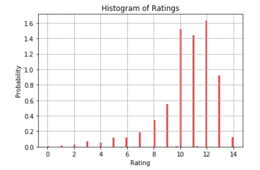

According to this analysis,the most common 5 ratings are 9,10,11,12,13, and ratings 11 and 12 are really common. However, there are lots of ratings less than 10. Are these dogs are really good? It depends to the person who rates.

Most of the people like it or not? I again analyzed favorites count vs ratings.

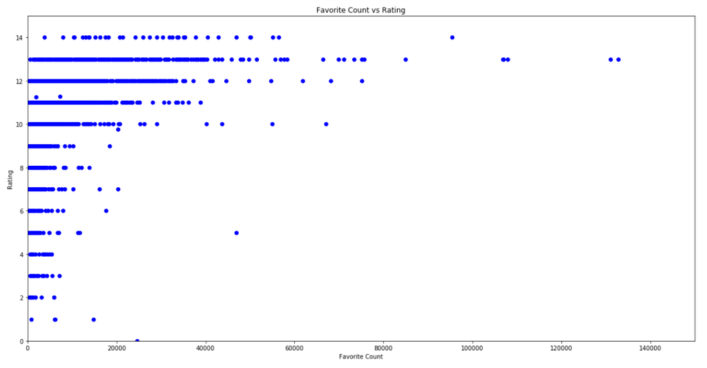

Looking at the correlation coefficient calculated (0.307) and scatter plot, it can be inferred that dog ratings and favorite counts are actually correlated.

Are these ratings found to be interesting to retweet?

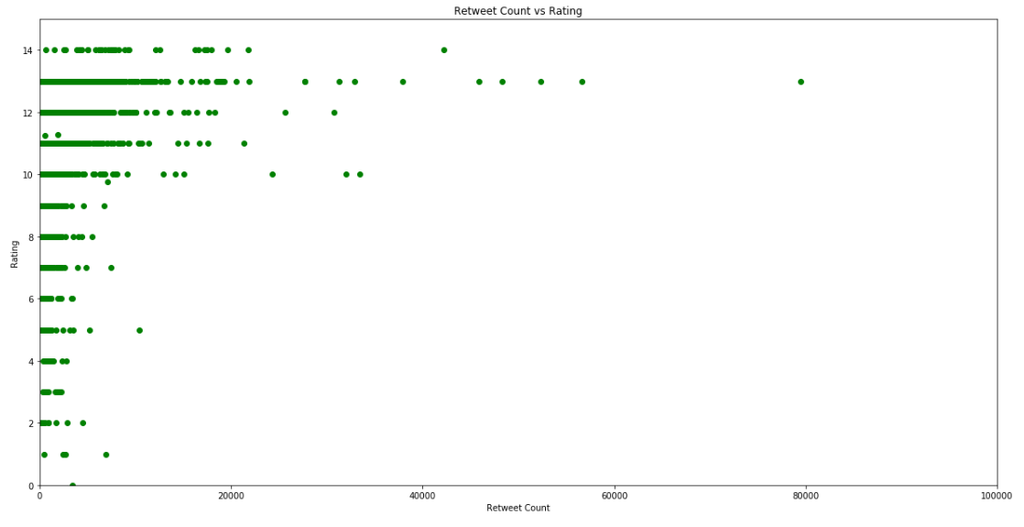

Again, ratings are retweet counts are positively correlated to each other (correlation coefficient: 0.410508)

These findings show that people rated these dogs high too.

## Dog stages and Ratings

In #WeRateDogs book on Amazon some dog stages are explained.

How often We Rate Dogs(@dog_rates) uses these words?

- pupper %11.3 of tweets
- doggo %3.4 of tweets
- floof %1.7 of tweets
- puppo %1.3 of tweets

Which has the highest average ratings?

- pupper 10.59
- doggo 11.87
- floof 11.71
- puppo 12.11

## Which dog breed is most commonly rated?

The most common dog breed is golden retriever

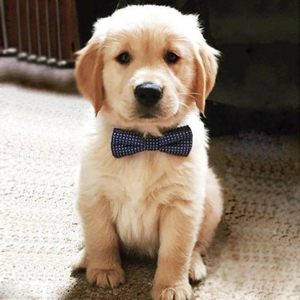